# Plot Methods

## Ploting collections of spectra

```r
two_suns.mspct <- source_mspct(list(sun1 = sun.spct, sun2 = sun.spct * 2))
```

Plot as separate plots. This approach is specially useful with heterogeneous generic_mspct objects, although it works with any collection of spectra.

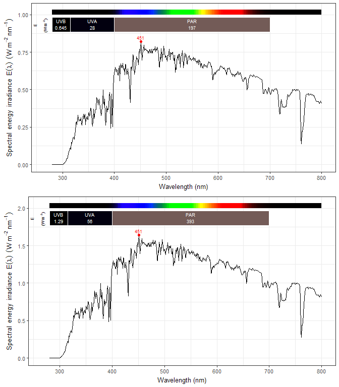

```r
multiplot(plotlist = mslply(two_suns.mspct, plot))
```

Plot with one panel per spectrum by first converting the collection-of-spectra into a spectrum object.

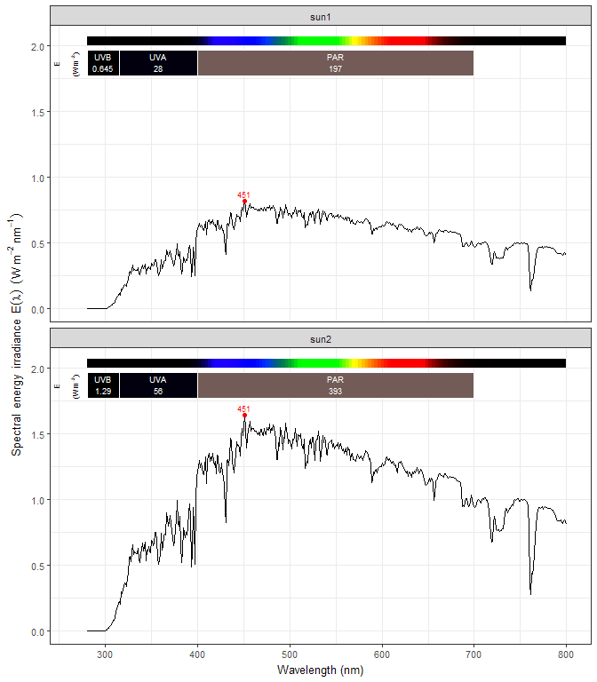

```r
plot(rbindspct(two_suns.mspct)) + facet_wrap(~spct.idx, ncol = 1)
```

Plot using grouping by first converting the collection-of-spectra into a spectrum object.

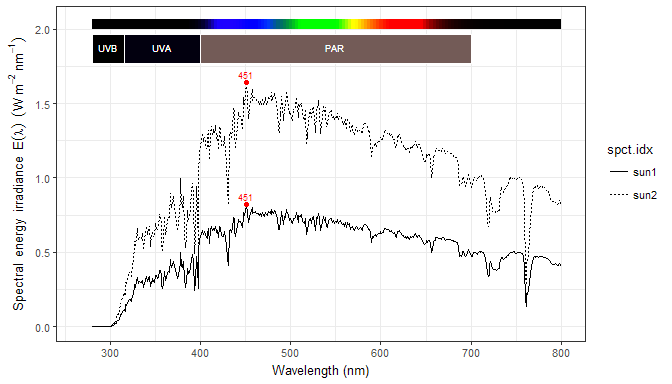

```r
plot(rbindspct(two_suns.mspct),
     annotations = c("-", "summaries")) +
  aes(linetype = spct.idx)
```

Using colors is slightly more involved as the identity scale is in use. For this same reason no color key in generated automatically, and a single peak is found unless we change the default span. (In the case of more than two spectra it is easier to use `plyr::mapvalues` instead of several nested `ifelse` calls.)

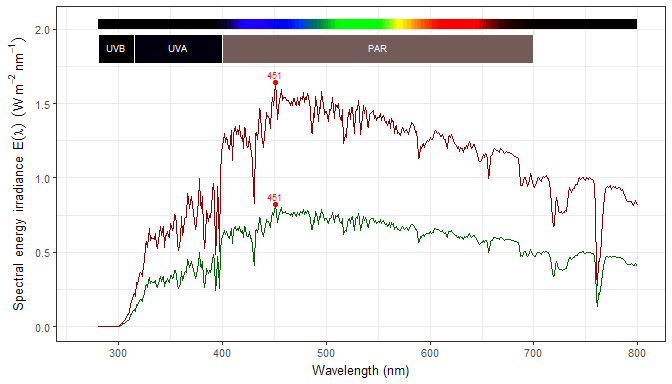

```r
plot(rbindspct(two_suns.mspct),
     annotations = c("-", "summaries"), span = 301) +
  aes(color = ifelse(spct.idx == "sun1", "darkgreen", "darkred"))
```

Plots created with `plot()` method can be used as the starting point for customizations.

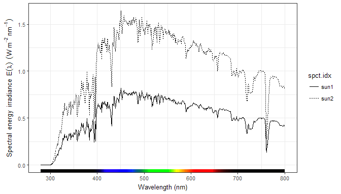

```r
plot(rbindspct(two_suns.mspct), annotations = "") +
  aes(linetype = spct.idx) +
  wl_guide(ymax = -0.05)
```

Here we replace the default peaks annotations with a custom one, but still take advantage of other defaults like nice axis labels and other annotations.

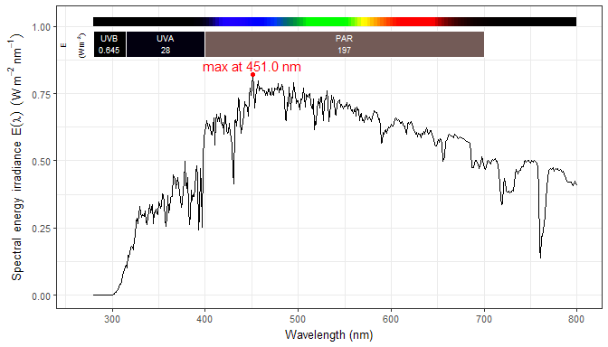

```r
plot(sun.spct, annotations = c("-", "peaks")) +
  stat_peaks(span = NULL, color = "red") +
  stat_peaks(span = NULL, geom = "text",
             label.fmt = "max at %3.1f nm",
             vjust = -0.4, color = "red")
```

Plot using “lower-level” functions. See the ‘User Guide’ for additional details.

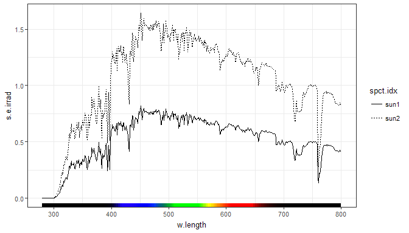

```r
ggplot(rbindspct(two_suns.mspct)) +
  aes(linetype = spct.idx) +
  wl_guide(ymax = -0.05) +
  geom_line()
```

## Ploting wavebands

A `plot()` method for `waveband` objects is also provided.

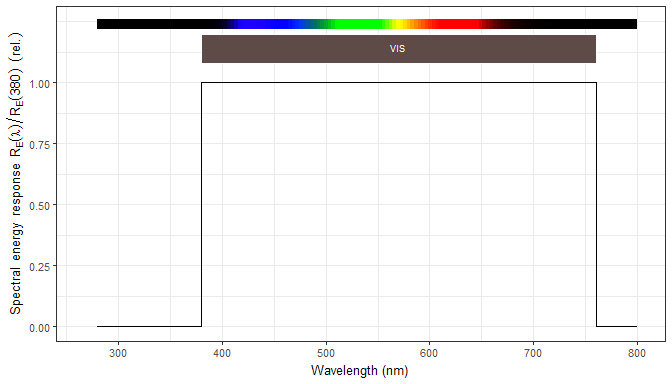

```r
plot(VIS())
```

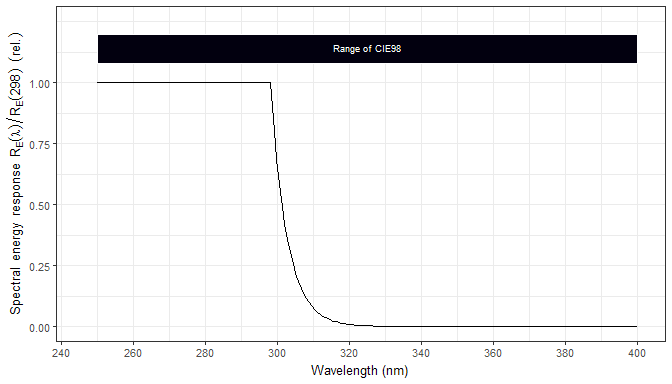

```r
plot(CIE(), range = CIE(), annotations = c("-", "color.guide"))
```

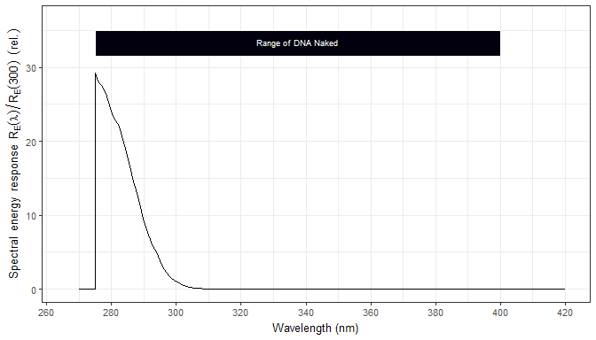

```r
plot(DNA_N(), range = c(270, 420), annotations = c("-", "color.guide"))
```